# TrabajoSegmentacionDefinitivoTAE

## Trabajo Segmentación TAE

Integrantes:

- Edhy Santiago Marín Arbeláez
- Sebastián López restrepo
- Valentín de la Rosa Rueda
- Juan José Martínez Posada
- David González Jiménez

### Importar librerías

```python
import pandas as pd
import numpy as np
import matplotlib.pyplot as plt
import seaborn as sns

# Tratamiento de datos
# ==============================================================================
import numpy as np
import pandas as pd
import statsmodels.api as sm

# Gráficos
# ==============================================================================
import matplotlib.pyplot as plt
import matplotlib.font_manager
from matplotlib import style
style.use('ggplot') or plt.style.use('ggplot')

# Preprocesado y modelado
# ==============================================================================
from sklearn.decomposition import PCA
from sklearn.pipeline import make_pipeline
from sklearn.preprocessing import StandardScaler
from sklearn.preprocessing import scale

# Clusters y Dendograma
# ==============================================================================
import scipy.cluster.hierarchy as sch
from scipy.cluster.hierarchy import dendrogram, linkage, fcluster

# Configuración warnings
# ==============================================================================
import warnings
warnings.filterwarnings('ignore')
```

### Cargar base de datos

```python
datos = pd.read_csv('base_trabajo_segmentacion.csv',delimiter=';')
datos = datos.drop(['nit'], axis=1)
```

### Descripción base de datos

La base de datos contiene 46 variables que describe el comportamiento de los servicio que los clientes de un banco utilizan

### Separar los datos

Se separan el conjunto de datos de la siguiente forma:

1. Entradas de valor medio anual en todos los canales.
2. Entradas de transacción mensual promedio en todos los canales.
3. Salidas de valor medio anual en todos los canales.
4. Salidas de transacción mensual promedio en todos los canales.

Todos los subconjuntos de datos tienen integradas las variables de estado financiero asociadas a cada usuario.

```python
en_vm = pd.concat((datos.iloc[1: , :11], datos.iloc[1: , 30:46]), axis = 1)
en_tx = pd.concat((datos.iloc[1: , 11:22], datos.iloc[1: , 30:46]), axis = 1)
sal_vm = pd.concat((datos.iloc[1: , 22:26], datos.iloc[1: , 30:46]), axis = 1)
sal_tx = datos.iloc[1: , 26:46]
```

# Análisis estadístico

## Entradas Valor Promedio Anual del Ticket

### Construcción de la matriz de Componentes Principales

```python
pca_pipe_en_vm = make_pipeline(StandardScaler(), PCA())
pca_pipe_en_vm.fit(en_vm)
# Se extrae el modelo entrenado del pipeline
modelo_pca_en_vm = pca_pipe_en_vm.named_steps['pca']
#print(modelo_pca_en_vm.components_)
```

### Gráfico de Varianza Acumulada de los Componentes Principales

```
------------------------------------------
Porcentaje de varianza explicada acumulada
------------------------------------------
[0.14621725 0.27742726 0.35970125 0.43122373 0.49748399 0.55296617
 0.60596401 0.65182227 0.69454197 0.73389465 0.7698022  0.80428138
 0.83508206 0.86506013 0.89307378 0.91945387 0.9377411  0.95095661
 0.96183471 0.96777686 0.97339038 0.97878282 0.98393127 0.98878153
 0.99309906 0.99707844 1.        ]
```

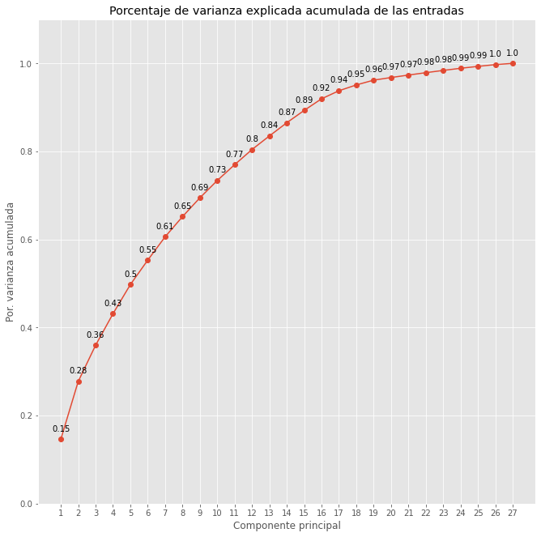

```python
# Porcentaje de varianza explicada acumulada [en_vm]
# ==============================================================================
prop_varianza_acum = modelo_pca_en_vm.explained_variance_ratio_.cumsum()
print('------------------------------------------')
print('Porcentaje de varianza explicada acumulada')
print('------------------------------------------')
print(prop_varianza_acum)

fig, ax = plt.subplots(nrows=1, ncols=1, figsize=(11, 11))
ax.plot(
    np.arange(len(en_vm.columns)) + 1,
    prop_varianza_acum,
    marker = 'o'
)

for x, y in zip(np.arange(len(en_vm.columns)) + 1, prop_varianza_acum):
    label = round(y, 2)
    ax.annotate(
        label,
        (x,y),
        textcoords="offset points",
        xytext=(0,10),
        ha='center'
    )

ax.set_ylim(0, 1.1)
ax.set_xticks(np.arange(modelo_pca_en_vm.n_components_) + 1)
ax.set_title('Porcentaje de varianza explicada acumulada de las entradas')
ax.set_xlabel('Componente principal')
ax.set_ylabel('Por. varianza acumulada')
```

Basados en la gráfica de varianza acumulada se tienen en cuenta las primeras 16 componentes principales para seguir realizando el análisis estadístico, con esto se reduce la base de datos de 27 variables a 16 componentes y estas explican aproximadamente un 90% de la variabilidad total.